# Advanced Plotting in R

Now that you’ve mastered the basics of plotting in RStudio, it’s time to learn some more advanced skills! If you need a refresher on what was covered on the *Introduction to Plotting in R* helpsheet, click [**here**](http://mjnelson.org/PLSC309/Introduction_to_Plotting_in_R.html) to catch up!

First, let’s load in the data. The data used in the following examples are nearly identical to those used in the introduction helpsheet.

```r
#Reading .csv file into R
example.data <- read.csv(file = "~/Dropbox/309/RHelp/example.data.csv")
```

The first plot I am going to create is one from the previous worksheet. This plot examines the relationship between high school dropout rates and poverty rates in 2015.

Here it is again:

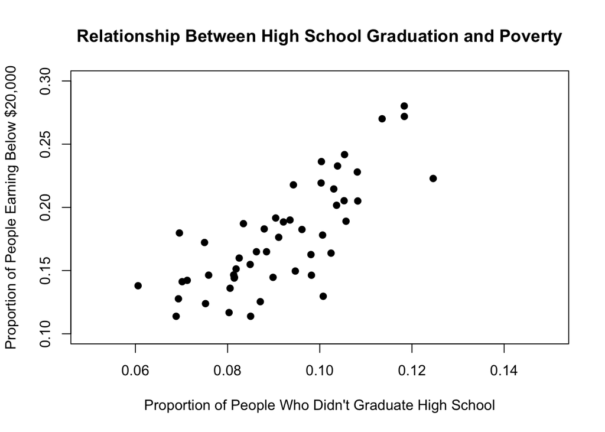

```r
#Plotting high school graduation rates and propotion of those who are in poverty
plot(x = example.data$highschool.drop, y = example.data$income.20,
     xlab = "Proportion of People Who Didn't Graduate High School",
     ylab = "Proportion of People Earning Below $20,000",
     main = "Relationship Between High School Graduation and Poverty",
     pch = 19,
     xlim = c(0.05, 0.15),
     ylim = c(0.1, 0.3))
```

This still looks like a great graph that we can derive conclusions from. That being said, there is usually always more you can do to a plot to make it more informative.

Say you wanted to examine the states in the Southern region of the country on the same graph in which everything else is plotted. It is quite easy to do this in R! There will be many times in the future when you’re plotting in R that you’ll want to use only a portion of your data. In order to extract snippets of data based on a condition, such as the Southern region of the country, you must subset your data.

### Subsetting with subset() Command

Subsetting data can be done in many ways, but is usually done by utilizing the *subset()* command or [square brackets]. The *subset()* command takes two arguments: the data to be subsetted, and the condition upon which it is to be subsetted. For example, if you want subset the dataset *example.data* by the condition that the state is in the south, the command would look like this: *subset(example.data, region == 1)*. This can be read in layman’s terms as, “pull out all data from *example.data* where the region is equal to 1 (otherwise known as a Southern state).”

Here it is in practice:

```r
#Subsetting data by the south using subset()
subset(example.data, region == 1)
```

```
##    year          state region income.20 highschool.drop south   over.65
## 7  2015       Delaware      1 0.1446358      0.08985980     1 0.1650024
## 23 2015       Virginia      1 0.1296634      0.10074339     1 0.1343410
## 24 2015        Alabama      1 0.2228415      0.12460138     1 0.1501655
## 25 2015       Arkansas      1 0.2417376      0.10537122     1 0.1595824
## 26 2015        Florida      1 0.2178083      0.09427535     1 0.1786484
## 27 2015        Georgia      1 0.2016532      0.10364316     1 0.1273966
## 28 2015      Louisiana      1 0.2801876      0.11832416     1 0.1221628
## 29 2015    Mississippi      1 0.2719123      0.11834410     1 0.1320594
## 30 2015 North Carolina      1 0.2192935      0.10028845     1 0.1465478
## 31 2015 South Carolina      1 0.2050520      0.10823521     1 0.1563509
## 32 2015          Texas      1 0.1890213      0.10568954     1 0.1185146
## 33 2015       Kentucky      1 0.2327357      0.10385405     1 0.1580847
## 34 2015       Maryland      1 0.1238453      0.07520950     1 0.1344274
## 35 2015       Oklahoma      1 0.2052411      0.10527639     1 0.1442612
## 36 2015      Tennessee      1 0.2145506      0.10303495     1 0.1580179
## 37 2015  West Virginia      1 0.2700782      0.11352215     1 0.1757690
```

R printed all of the rows whose *region* value was “1”, otherwise coded as a Southern state. So it worked! We now have data on only Southern states. Typically you’d want to assign this subsetted data to a new variable that can be utilized in whatever you wish to do.

### Subsetting Data by [square brackets]

The other way to subset data is through the use of [square brackets]. Applying these brackets to the end of a dataset tells R what parameters to use to extract your data. These brackets take two “arguments”, the row conditions and the column conditions. If you want to just pull out the entire dataset, subsetted by one row condition (i.e. if a state is in the South), then you can leave the column “argument” blank.

Here is an example of subsetting the data based on if a state is based in the south:

```r
#Subsetting data by the south using  [square brackets]
example.data[example.data$region == 1, ]
```

```
##    year          state region income.20 highschool.drop south   over.65
## 7  2015       Delaware      1 0.1446358      0.08985980     1 0.1650024
## 23 2015       Virginia      1 0.1296634      0.10074339     1 0.1343410
## 24 2015        Alabama      1 0.2228415      0.12460138     1 0.1501655
## 25 2015       Arkansas      1 0.2417376      0.10537122     1 0.1595824
## 26 2015        Florida      1 0.2178083      0.09427535     1 0.1786484
## 27 2015        Georgia      1 0.2016532      0.10364316     1 0.1273966
## 28 2015      Louisiana      1 0.2801876      0.11832416     1 0.1221628
## 29 2015    Mississippi      1 0.2719123      0.11834410     1 0.1320594
## 30 2015 North Carolina      1 0.2192935      0.10028845     1 0.1465478
## 31 2015 South Carolina      1 0.2050520      0.10823521     1 0.1563509
## 32 2015          Texas      1 0.1890213      0.10568954     1 0.1185146
## 33 2015       Kentucky      1 0.2327357      0.10385405     1 0.1580847
## 34 2015       Maryland      1 0.1238453      0.07520950     1 0.1344274
## 35 2015       Oklahoma      1 0.2052411      0.10527639     1 0.1442612
## 36 2015      Tennessee      1 0.2145506      0.10303495     1 0.1580179
## 37 2015  West Virginia      1 0.2700782      0.11352215     1 0.1757690
```

Notice how the two different methods of subsetting gave us the same thing?

### Changing Point Color by Subsetting

Now that you know how to subset in R, let’s go back to the previous graph. As I said, it’s still a great graph, but we can make it more informative through the use of subsetting. For this example let’s plot the same graph, but this time let’s make it so that the states that reside in the South appear as red dots on the plot.

To do this, we’ll need to create a new variable and utilize the *col* argument once again. This new variable is going to contain the colors that will be applied to the *col* argument. To start, we need to create a base color. We can make this one black, since it is the default base color in R. To do this, we’ll apply “black” to our new variable *region.color*.

```r
#Creating base color variable
example.data$region.color <- "black"

#Printing variable to screen to show that all cells contain "black"
print(example.data$region.color)
```

```
##  [1] "black" "black" "black" "black" "black" "black" "black" "black"
##  [9] "black" "black" "black" "black" "black" "black" "black" "black"
## [17] "black" "black" "black" "black" "black" "black" "black" "black"
## [25] "black" "black" "black" "black" "black" "black" "black" "black"
## [33] "black" "black" "black" "black" "black" "black" "black" "black"
## [41] "black" "black" "black" "black" "black" "black" "black" "black"
## [49] "black" "black"
```

Perfect. This added a new column to the data that put the text “black” in every single cell. Next, we’ll want to designate which states are red (states that reside in the South) and apply that to the variable. This is where subsetting comes in.

We want to only apply the color “red” to those states which reside in the South. To do this, we’ll utilize [square brackets] to subset the data and apply “red” to those states. Here is the example:

```r
#Creating color for Southern states
example.data$region.color[example.data$south == 1] <- "red"

#Printing variable to screen to show that states that reside in the south have been coded as "red"
print(example.data$region.color)
```

```
##  [1] "black" "black" "black" "black" "black" "black" "red"   "black"
##  [9] "black" "black" "black" "black" "black" "black" "black" "black"
## [17] "black" "black" "black" "black" "black" "black" "red"   "red"
## [25] "red"   "red"   "red"   "red"   "red"   "red"   "red"   "red"
## [33] "red"   "red"   "red"   "red"   "red"   "black" "black" "black"
## [41] "black" "black" "black" "black" "black" "black" "black" "black"
## [49] "black" "black"
```

In layman’s term, the code above can be read as: “apply ‘red’ to all cells in *region.color* where *south* equals 1 (state resides in the South).” We now have all that we need to plot a graph that disguinshes Southern states from non-Southern states. Since all of our “colors” are in the variable *region.color*, all that we must do now is apply this variable to the argument *col*.

Here is exactly that:

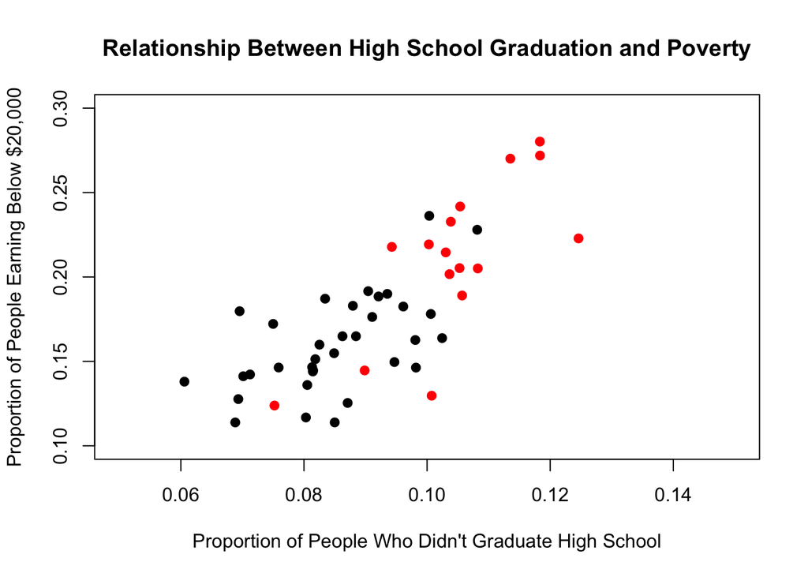

```r
#Plotting high school graduation rates and propotion of those who are in poverty, as well as changing Southern states to red
plot(x = example.data$highschool.drop, y = example.data$income.20,
     xlab = "Proportion of People Who Didn't Graduate High School",
     ylab = "Proportion of People Earning Below $20,000",
     main = "Relationship Between High School Graduation and Poverty",
     pch = 19,
     xlim = c(0.05, 0.15),
     ylim = c(0.1, 0.3),
     col = example.data$region.color)
```

There we go! We now have a graph that tells us which states reside in the South in red, and which states do not in black. Let’s add a legend to make this more clear.

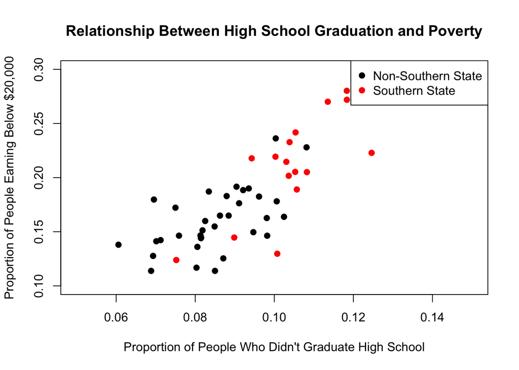

```r
#Plotting high school graduation rates and propotion of those who are in poverty, s well as changing Southern states to red
plot(x = example.data$highschool.drop, y = example.data$income.20,
     xlab = "Proportion of People Who Didn't Graduate High School",
     ylab = "Proportion of People Earning Below $20,000",
     main = "Relationship Between High School Graduation and Poverty",
     pch = 19,
     xlim = c(0.05, 0.15),
     ylim = c(0.1, 0.3),
     col = example.data$region.color)

#Adding a legend
legend("topright", legend = c("Non-Southern State", "Southern State"), pch = c(19,19), col = c("black", "red"))
```

### Putting Two Plots Together

There are many times where it will be beneficial to view two plots side by side to look for similarites. In R, it is possible to do just that. Using the *par()* function, two plots can be pasted together to create one figure! To demonstrate this we’ll compare the plot examining the relationship between high school graduation rates and poverty, and a new plot examining the relationship between the proportion of the population over the age of 65 and poverty.

Here is what the new plot looks like:

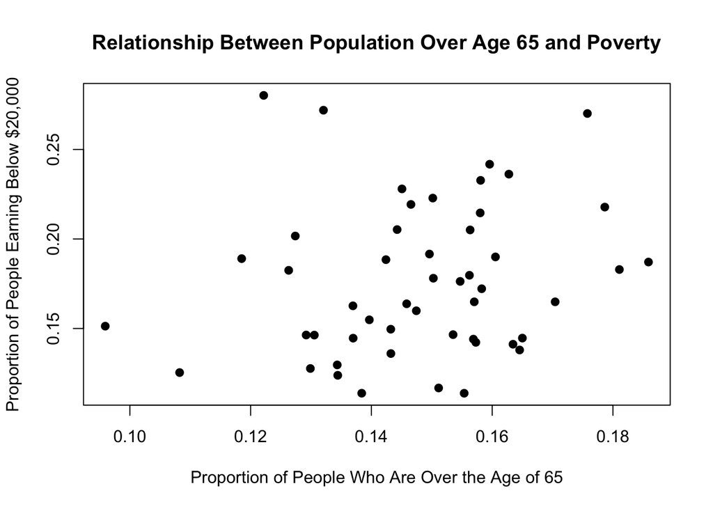

```r
#Plotting age over 65 and poverty rate
plot(x = example.data$over.65, y = example.data$income.20,
     xlab = "Proportion of People Who Are Over the Age of 65",
     ylab = "Proportion of People Earning Below $20,000",
     main = "Relationship Between Population Over Age 65 and Poverty",
     pch = 19)
```

To combine these to plots, we must use the *mfrow* argument within the *par()* function. This argument creates a matrix of rows by columns which tells R how to paste together the plots. If you only have two plots, and you want them to be pasted right next to each other, then you would to create a matrix of 1 by 2 (1 row by 2 columns). Make sure to use the *c()* function to place these values into a vector! It is also important that the *par()* function is placed before the code that creates both graphs.

This is what it looks like to paste the plots side by side:

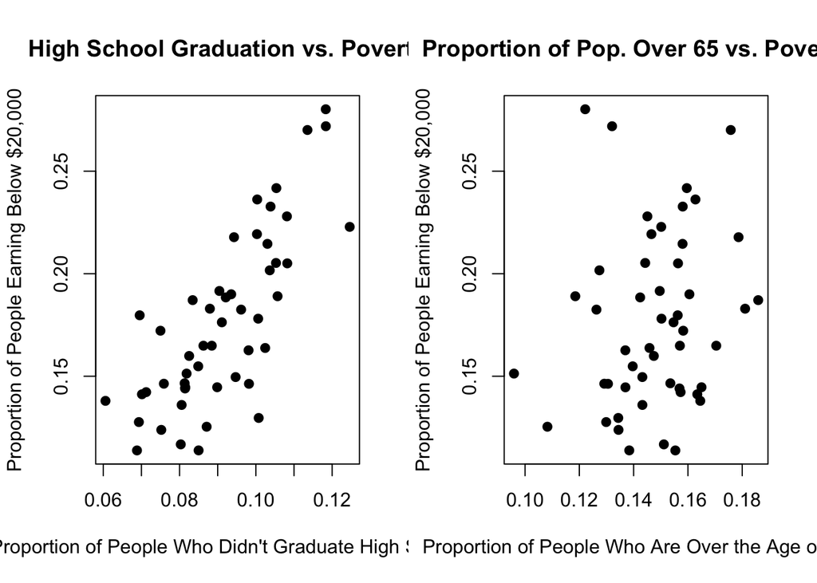

```r
#Combining the two graphs side by side
par(mfrow = c(1,2))

#Plotting poverty rates and propotion of those who are in poverty
plot(x = example.data$highschool.drop, y = example.data$income.20,
     xlab = "Proportion of People Who Didn't Graduate High School",
     ylab = "Proportion of People Earning Below $20,000",
     main = "High School Graduation vs. Poverty",
     pch = 19)

#Plotting age over 65 and poverty rate
plot(x = example.data$over.65, y = example.data$income.20,
     xlab = "Proportion of People Who Are Over the Age of 65",
     ylab = "Proportion of People Earning Below $20,000",
     main = "Proportion of Pop. Over 65 vs. Poverty",
     pch = 19)
```

Now that we’ve succesfully pasted the plots together, let’s make the plot look nicer by shrinking the font size to fit within the figure. To do this, we’ll need to employ the *cex.main*, *cex.axis*, and *cex.lab* arguments. Just as we used *cex* in the previous helpsheet to change the size of the points on the plot, we’ll use a variation of this argument to change the size of the font of the main, x-axis, and y-axis labels.

There is no way to know for sure what number is going to be the right one to apply to these arguments, so it’s best to play around with them until you find one that works. Below, I apply .8 to *cex* to get a font size that is .8 the size of the default:

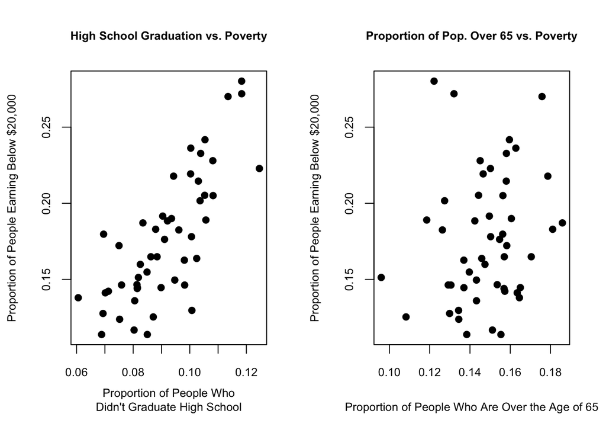

```r
#Combining the two graphs with altered font sizes
par(mfrow = c(1,2), cex.main = .8, cex.axis = .8, cex.lab = .8)

#Plotting poverty rates and propotion of those who are in poverty
plot(x = example.data$highschool.drop, y = example.data$income.20,
     xlab = "Proportion of People Who\nDidn't Graduate High School",
     ylab = "Proportion of People Earning Below $20,000",
     main = "High School Graduation vs. Poverty",
     pch = 19)

#Plotting age over 65 and poverty rate
plot(x = example.data$over.65, y = example.data$income.20,
     xlab = "Proportion of People Who Are Over the Age of 65",
     ylab = "Proportion of People Earning Below $20,000",
     main = "Proportion of Pop. Over 65 vs. Poverty",
     pch = 19)
```

The last thing we may want to do is to add a title across two plots. We do this by using the `oma` argument to change the Outer MArgins of the plot and then adding the main title in a separate command (mtext):

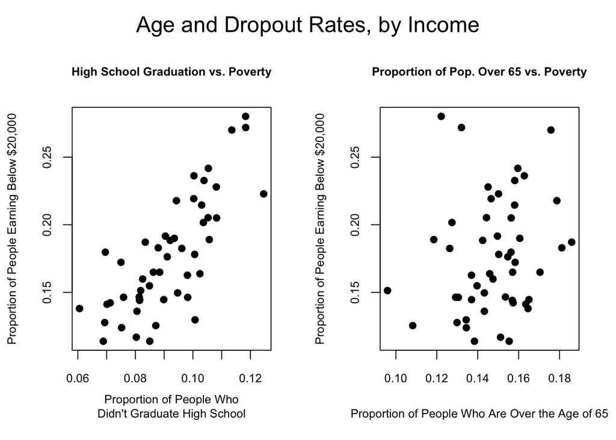

```r
#Combining the two graphs with altered font sizes
par(mfrow = c(1,2),oma = c(0, 0, 2, 0), cex.main = .8, cex.axis = .8, cex.lab = .8)

#Plotting poverty rates and propotion of those who are in poverty
plot(x = example.data$highschool.drop, y = example.data$income.20,
     xlab = "Proportion of People Who\nDidn't Graduate High School",
     ylab = "Proportion of People Earning Below $20,000",
     main = "High School Graduation vs. Poverty",
     pch = 19)

#Plotting age over 65 and poverty rate
plot(x = example.data$over.65, y = example.data$income.20,
     xlab = "Proportion of People Who Are Over the Age of 65",
     ylab = "Proportion of People Earning Below $20,000",
     main = "Proportion of Pop. Over 65 vs. Poverty",
     pch = 19)

mtext("Age and Dropout Rates, by Income", outer = TRUE, cex = 1.5)
```

### Applying Text to a Graph

There will be other times in the future where you may want to label points on a plot. To do this in R, you use the *text()* function. This function takes the text you provide it and places it on the plot in the place you specify. *text()* takes in three main arguments: the text’s coordinates on the x-axis (*x*), the text’s coordinates on the y-axis (*y*), and the text you wish to apply (*label*). It is important that this function is placed after your *plot()* function.

Below, I’m telling R to apply the state names to their position on the plot:

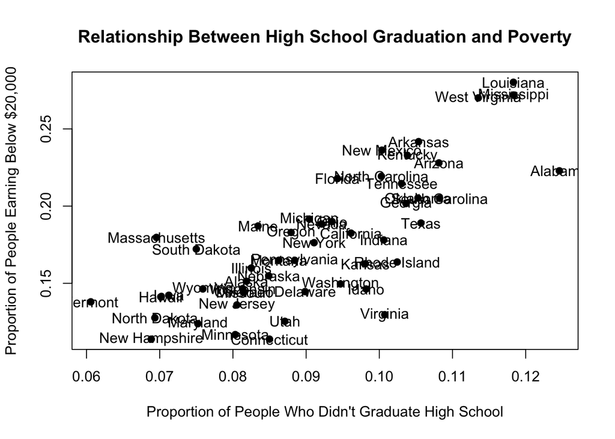

```r
#Adding text to graph
plot(x = example.data$highschool.drop, y = example.data$income.20,
     xlab = "Proportion of People Who Didn't Graduate High School",
     ylab = "Proportion of People Earning Below $20,000",
     main = "Relationship Between High School Graduation and Poverty",
     pch = 19)

#Applying labels to points
text(x = example.data$highschool.drop, y = example.data$income.20, labels = example.data$state)
```

This graph is pretty cluttered, and there probably aren’t a lot of situations where we would want all of the states to be labeled on one plot. Let’s say we want to highlight only one state, Pennsylvania. To do this, we’ll need to subset the data. In the example below I’m going to do just that using [square brackets]. The only part of the code that will be changing in the *text()* function is the addition of these brackets to the end of each variable, plus the addition of the *cex* and *pos* arguments.

Here is that applied:

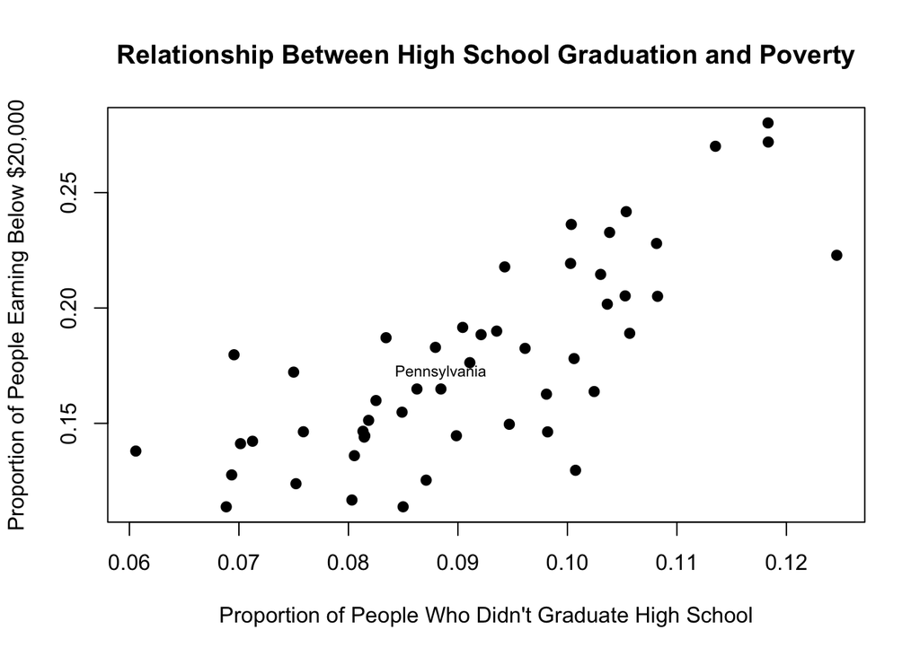

```r
#Adding text to graph
plot(x = example.data$highschool.drop, y = example.data$income.20,
     xlab = "Proportion of People Who Didn't Graduate High School",
     ylab = "Proportion of People Earning Below $20,000",
     main = "Relationship Between High School Graduation and Poverty",
     pch = 19)

text(x = example.data$highschool.drop[example.data$state == "Pennsylvania"], y = example.data$income.20[example.data$state == "Pennsylvania"], labels = example.data$state[example.data$state == "Pennsylvania"], cex = 0.7, pos = 3)
```

### Creating Dotcharts

Another plot that is useful to make in R is called a dotchart. Dotcharts are useful when wanting to examine groups over one variable. For exmaple, this type of chart would be useful in examining how poverty rates vary among the states.

To call this function, we use *dotchart()*:

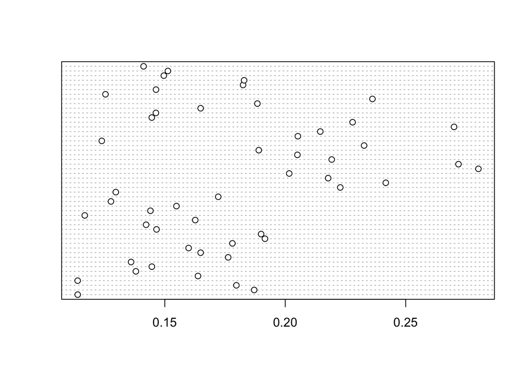

```r
#Creating dotchart of poverty rates
dotchart(example.data$income.20)
```

This graph doesn’t tell us very much, let’s add some labels.

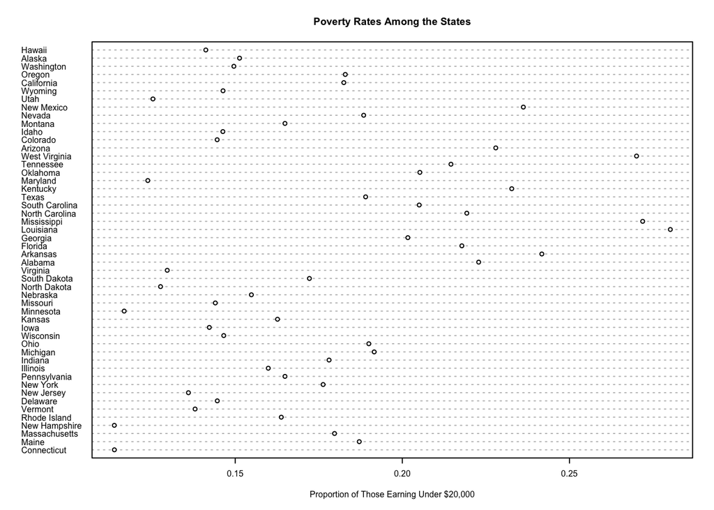

```r
#Creating dotchart of poverty rates, adding labels, and changing size of label text
dotchart(example.data$income.20, cex = .5,
         labels = example.data$state,
         xlab = "Proportion of Those Earning Under $20,000",
         main = "Poverty Rates Among the States")
```

This plot looks a lot better! With labels and a nicer format, we can start to pull some information out of this plot. The last thing that would make this easier to understand would be to put these states in descending order.

Here it is in practice:

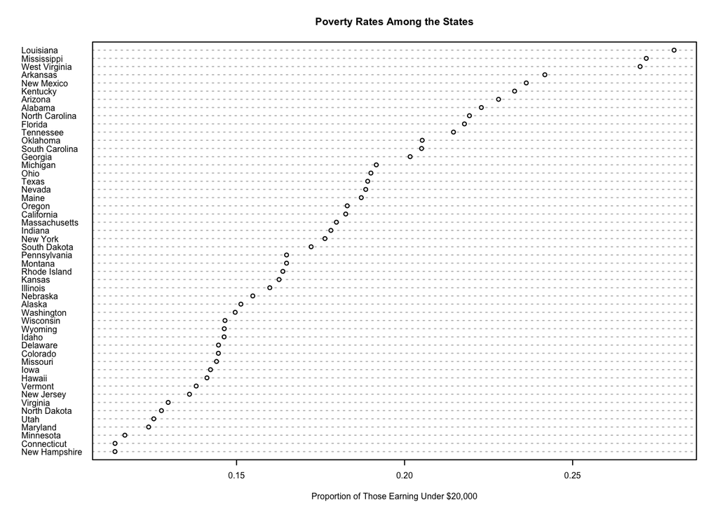

```r
#Ordering values from greatest to least
example.data <- example.data[order(example.data$income.20), ]


#Creating dotchart of poverty rates, adding labels, and changing size of label text
dotchart(example.data$income.20, cex = .5,
         labels = example.data$state,
         xlab = "Proportion of Those Earning Under $20,000",
         main = "Poverty Rates Among the States")
```

Looks good! From this chart we can see that Louisiana has the highest poverty rate in the nation while New Hampshire has the lowest.

Helpsheet made by Jacob Ryan.